# Histogram Tutorial

Cleary Johnston

2017-10-10

Histograms provide a good way to visualize data and communicate the frequency distribution or shape of the data. For example, we can take a look at the body weight distribution of baseball players. For this we will need the sqldf, Lahman, and ggplot2 packages. We then can begin by extracting the data we would like to see represented by using a query and storing that information back into result. Now that we have the information stored and can use ggplot to visualize it. In this case we are using geom_histogram to indicaate the type of graph we need. After we indicate the graph we will need to tell ggpot where the data is located (result) and add other specifics to the graph by using the aes comand. You can see that I used color, fill, and bins to help better communicate the data set. Finally using ggtitle we can add a title to the graph. After all that we have an easy to read histogram that commuicates our frequency distribution well.

```r
library(sqldf)
```

```r
library(Lahman)
library(ggplot2)
```

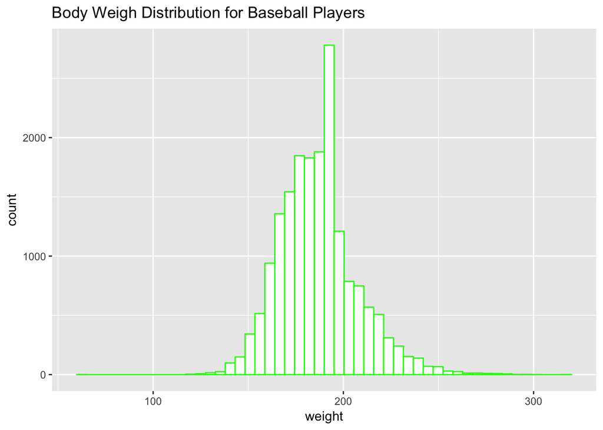

```r
# extracting data----------------

query<-"SELECT weight
FROM Master"

result<-sqldf(query)

# visualizing data-------------

ggplot()+
  geom_histogram(data=result,aes(x=weight),color="green",fill="white",bins="50")+
  ggtitle("Body Weigh Distribution for Baseball Players")
```